# Google Data Analytics Capstone Project: Cyclist Case Study

Cameron Hutchinson

January 6, 2023

### Introduction

This case study is part of the Google Data Analytics Capstone. In order to answer key business questions, we will go through the following steps in the data analytics process:

- Ask
- Prepare
- Process
- Analyze
- Share
- Act

## Scenario

You are a junior data analyst working in the marketing analyst team at Cyclistic, a bike-share company in Chicago. The director of marketing believes the company’s future success depends on maximizing the number of annual memberships. Therefore, your team wants to understand how casual riders and annual members use Cyclistic bikes differently. From these insights, your team will design a new marketing strategy to convert casual riders into annual members. But first, Cyclistic executives must approve your recommendations, so they must be backed up with compelling data insights and professional data visualizations.

### About the Company

In 2016, Cyclistic launched a successful bike-share offering. Since then, the program has grown to a fleet of 5,824 bicycles that are geotracked and locked into a network of 692 stations across Chicago. The bikes can be unlocked from one station and returned to any other station in the system anytime. Until now, Cyclistic’s marketing strategy relied on building general awareness and appealing to broad consumer segments. One approach that helped make these things possible was the flexibility of its pricing plans: single-ride passes, full-day passes, and annual memberships. Customers who purchase single-ride or full-day passes are referred to as casual riders. Customers who purchase annual memberships are Cyclistic members.

### Business Task

Derive insights on the differences between casual riders and member rides through data analysis.Design marketing strategies aimed at converting casual riders into annual members.

### Ask

We are required to answer the following questions:

**1. What is the problem you are trying to solve?**

We are trying to differentiate casual and member rider usage to increase memberships.

**2. How can your insights drive business decisions?**

By analyzing the behaviors and differences between the two groups, we can derive recommendations and an effective marketing campaign for our customers.

### Prepare

Our analysis wil use historical data avaliable [here](https://divvy-tripdata.s3.amazonaws.com/index.html).

We will be using R to efficiency view, manipulate, and visualize data.

**Load Packages.**

```r
#Loading Packages

library(tidyverse)
library(janitor)
library(lubridate)
```

**Import our data into R Studio.**

```r
#Reading datasets

Jan2021 <- read_csv("Trip_Data/2021_01.csv")
Feb2021 <- read_csv("Trip_Data/2021_02.csv")
Mar2021 <- read_csv("Trip_Data/2021_03.csv")
#Apr2021 <- read_csv("Trip_Data/2021_04.csv")
#May2021 <- read_csv("Trip_Data/2021_05.csv")
#Jun2021 <- read_csv("Trip_Data/2021_06.csv")
#Jul2021 <- read_csv("Trip_Data/2021_07.csv")
#Aug2021 <- read_csv("Trip_Data/2021_08.csv")
#Sep2021 <- read_csv("Trip_Data/2021_09.csv")
#Oct2021 <- read_csv("Trip_Data/2021_10.csv")
#Nov2021 <- read_csv("Trip_Data/2021_11.csv")
#Dec2021 <- read_csv("Trip_Data/2021_12.csv")
```

**Merge our data into one Dataframe.**

```r
#Creating a Dataset <- bind_rows(datasets)

bike_df <- bind_rows(Jan2021, Feb2021, Mar2021)
```

```r
bike_df_2 <- bike_df
```

**View Column Names**

```r
colnames(bike_df_2)
```

```
##  [1] "ride_id"            "rideable_type"      "started_at"
##  [4] "ended_at"           "start_station_name" "start_station_id"
##  [7] "end_station_name"   "end_station_id"     "start_lat"
## [10] "start_lng"          "end_lat"            "end_lng"
## [13] "member_casual"
```

We have enough data to answer the following questons:

**1. Where is your data located?**

The data required for this case study is located in a folder in the files pane of R Studio

**2. How is the data organized?**

The available data is organised by month and is stored in a separate .csv file for every month.

**3. Are there any issues with bias or credibility in this data? Does the data ROCCC?**

The data has been recorded with the company’s own clients in mind, thus bias and credibility is not a problem. Additionally, the data is reliable, original, comprehensive, current and cited.

**4. How are you addressing licensing, privacy, security, and accessibility?**

The company has their own [license](https://divvy-tripdata.s3.amazonaws.com/index.html) over the dataset. Furthermore, the data is devoid of any personal information which can be traced to the riders. Hence, user privacy will not be threatened.

**5. How did you verify the data’s integrity?**

We will have to check if all the files have consistent columns and each column has the correct type of data.Addiitonally, we created a copy of the original dataset to uphold intergrity.

**6. How does it help you answer your question?**

This analysis will provide valuable insights about the customers and their riding style.

**7. Are there any problems with the data?** Data has issues with duplicate data, Null values, and invalid data.

### Process

In this step of the data analysis process, we will perform the following:

- Remove Empty Values
- Remove Duplicates
- Remove unneeded columns
- Make column names consistent and logical
- Add new columns to assist with our analysis

```r
#Removing Empty Values
remove_empty(bike_df_2, which = c())
```

```
## # A tibble: 374,952 × 13
##    ride_id       ridea…¹ started_at          ended_at            start…² start…³
##    <chr>         <chr>   <dttm>              <dttm>              <chr>   <chr>
##  1 E19E6F1B8D4C… electr… 2021-01-23 16:14:19 2021-01-23 16:24:44 Califo… 17660
##  2 DC88F20C2C55… electr… 2021-01-27 18:43:08 2021-01-27 18:47:12 Califo… 17660
##  3 EC45C94683FE… electr… 2021-01-21 22:35:54 2021-01-21 22:37:14 Califo… 17660
##  4 4FA453A75AE3… electr… 2021-01-07 13:31:13 2021-01-07 13:42:55 Califo… 17660
##  5 BE5E8EB4E726… electr… 2021-01-23 02:24:02 2021-01-23 02:24:45 Califo… 17660
##  6 5D8969F88C77… electr… 2021-01-09 14:24:07 2021-01-09 15:17:54 Califo… 17660
##  7 09275CC10F85… electr… 2021-01-04 05:05:04 2021-01-04 05:10:39 Califo… 17660
##  8 DF7A32A217AE… electr… 2021-01-14 15:07:00 2021-01-14 15:13:40 Califo… 17660
##  9 C2EFC62379EB… electr… 2021-01-09 09:57:55 2021-01-09 10:00:26 Califo… 17660
## 10 B9F73448DFBE… classi… 2021-01-24 19:15:38 2021-01-24 19:22:51 Califo… 17660
## # … with 374,942 more rows, 7 more variables: end_station_name <chr>,
## #   end_station_id <chr>, start_lat <dbl>, start_lng <dbl>, end_lat <dbl>,
## #   end_lng <dbl>, member_casual <chr>, and abbreviated variable names
## #   ¹rideable_type, ²start_station_name, ³start_station_id
```

```r
#Cleaning Names
bike_df_2 <- clean_names(bike_df_2,case='snake')

#Removing Duplicates
bike_df_2 <- distinct(bike_df_2)

#remove unneeded columns
bike_df_2 <- bike_df_2 %>%
  select(-c(start_station_id, end_station_id, start_lat, start_lng, end_lat, end_lng))

#Renaming member_casual column to member_type
bike_df_2 = bike_df_2 %>% rename(member_type = member_casual)

#Adding day_of_week Column using wday()
bike_df_2$day_of_week <- wday(bike_df_2$started_at, label = T, abbr = T)

#Adding Star_Hour Column using format(as.POSIXct))
bike_df_2$starting_hour <- format(as.POSIXct(bike_df_2$started_at, '%H'))

#Adding Month Column using format(as.Date)
bike_df_2$month <- format(as.Date(bike_df_2$started_at), '%m')

#Adding trip Duration Column using difftime()
bike_df_2$trip_duration <- difftime(bike_df_2$ended_at, bike_df_2$started_at, units = 'mins')

#convert trip_duration to numeric to run calculations
bike_df_2$trip_duration <- as.numeric(as.character(bike_df_2$trip_duration))

#Removing bad data where ride length is <= 0
bike_df_2<- bike_df_2[!(bike_df_2$trip_duration <=0),]
```

**Preview Dataframe**

```r
#Preview Dataframe

tibble(bike_df_2)
```

```
## # A tibble: 374,930 × 11
##    ride_id       ridea…¹ started_at          ended_at            start…² end_s…³
##    <chr>         <chr>   <dttm>              <dttm>              <chr>   <chr>
##  1 E19E6F1B8D4C… electr… 2021-01-23 16:14:19 2021-01-23 16:24:44 Califo… <NA>
##  2 DC88F20C2C55… electr… 2021-01-27 18:43:08 2021-01-27 18:47:12 Califo… <NA>
##  3 EC45C94683FE… electr… 2021-01-21 22:35:54 2021-01-21 22:37:14 Califo… <NA>
##  4 4FA453A75AE3… electr… 2021-01-07 13:31:13 2021-01-07 13:42:55 Califo… <NA>
##  5 BE5E8EB4E726… electr… 2021-01-23 02:24:02 2021-01-23 02:24:45 Califo… <NA>
##  6 5D8969F88C77… electr… 2021-01-09 14:24:07 2021-01-09 15:17:54 Califo… <NA>
##  7 09275CC10F85… electr… 2021-01-04 05:05:04 2021-01-04 05:10:39 Califo… <NA>
##  8 DF7A32A217AE… electr… 2021-01-14 15:07:00 2021-01-14 15:13:40 Califo… <NA>
##  9 C2EFC62379EB… electr… 2021-01-09 09:57:55 2021-01-09 10:00:26 Califo… <NA>
## 10 B9F73448DFBE… classi… 2021-01-24 19:15:38 2021-01-24 19:22:51 Califo… Wood S…
## # … with 374,920 more rows, 5 more variables: member_type <chr>,
## #   day_of_week <ord>, starting_hour <chr>, month <chr>, trip_duration <dbl>,
## #   and abbreviated variable names ¹rideable_type, ²start_station_name,
## #   ³end_station_name
```

We can now answer the following questions after processing the data:

**1. What tools are you choosing and why?**

I have chosen R to undertake this analysis project because this will allow me to handle huge amounts of data and take care of cleansing, analysing and visualising data in a better manner as compared to spreadsheets.

**2. Have you ensured your data’s integrity?**

Yes, the data has been thoroughly cleaned through the use of R functions.

**3. What steps have you taken to ensure that your data is clean?**

Duplicate values, irrelevant rows, and bad data have been removed.

**4. Have you documented your cleaning process so you can review and share those results?** Yes, all efforts undertaken by me have been recorded in this R Markdown Notebook.

### Analyze and Share

In this step of the Data Analysis Process, we will try to derive key insights from the cleaned data we have gathered, and use visualisation techniques to get a better understanding of the story the data is trying to tell.

**Performing summations**

```r
#total number of rides
nrow(bike_df_2)
```

```
## [1] 374930
```

The total number of rides between January and March are 374,930.

```r
#count member types
bike_df_2 %>% count(member_type)
```

```
## # A tibble: 2 × 2
##   member_type      n
##   <chr>        <int>
## 1 casual      112275
## 2 member      262655
```

Total casual riders are 112,275 and total member riders are 262,655.

```r
#total rides by bike type
bike_df_2 %>%
  group_by(rideable_type) %>%
  count(rideable_type)
```

```
## # A tibble: 3 × 2
## # Groups:   rideable_type [3]
##   rideable_type      n
##   <chr>          <int>
## 1 classic_bike  249244
## 2 docked_bike    19034
## 3 electric_bike 106652
```

Customers used 249,244 classic bikes, 19,034 docked bikes, and 106,652 electric bikes.

```r
#total rides by bike type by member type
bike_df_2 %>%
  group_by(member_type, rideable_type) %>%
  count(rideable_type)
```

```
## # A tibble: 6 × 3
## # Groups:   member_type, rideable_type [6]
##   member_type rideable_type      n
##   <chr>       <chr>          <int>
## 1 casual      classic_bike   59480
## 2 casual      docked_bike    19033
## 3 casual      electric_bike  33762
## 4 member      classic_bike  189764
## 5 member      docked_bike        1
## 6 member      electric_bike  72890
```

```r
#min, max, median, mean length of ride
summary(bike_df_2$trip_duration)
```

```
##     Min.  1st Qu.   Median     Mean  3rd Qu.     Max.
##     0.02     6.38    11.23    21.11    20.70 31681.65
```

The average ride length was 21.11 minutes.

**Data Visualizations**

Convert numbers out of scientific notation.

```r
#converts values out of scientific notation
options(scipen = 999)
```

**Graph 1: Number of Rides by Membership Type**

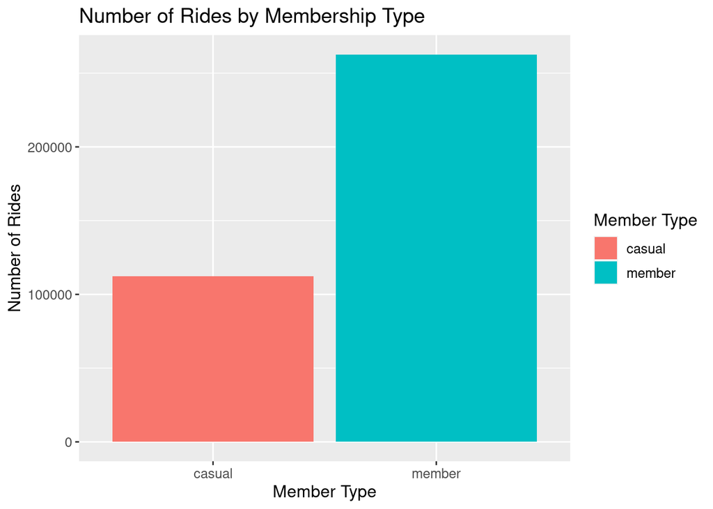

[figure not shown]

```r
#Plot number of rides by membership type

ggplot(bike_df_2, aes(member_type, fill = member_type)) + geom_bar() +
  labs(x = 'Member Type', y = 'Number of Rides', fill = 'Member Type', title= "Number of Rides by Membership Type", x= "Member type") +
  theme(text=element_text(size=12))
```

Based on this graph, members make up a larger portion of customers than casual riders.

**Graph 2: Number of Rides by Bicycle Type**

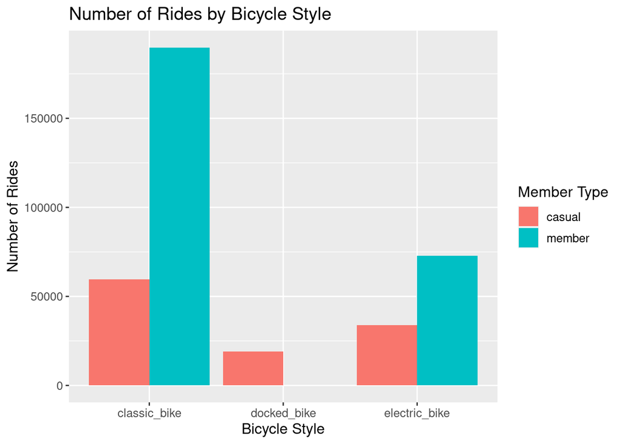

[figure not shown]

```r
#plot number of rides by bicycle style

ggplot(data = bike_df_2) +
  aes(x = rideable_type,fill = member_type) +
  geom_bar(position = 'dodge') +
  labs(x = 'Bicycle Style', y = 'Number of Rides', fill = 'Member Type', title = 'Number of Rides by Bicycle Style') +
  theme(text=element_text(size=12))
```

**Graph 3: Number of Rides by Day of Week.**

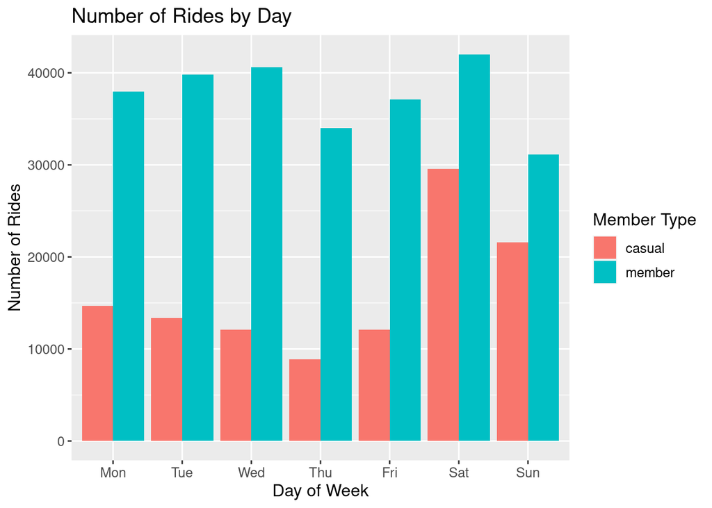

[figure not shown]

```r
#arrange days of the week in order

bike_df_2$day_of_week <- ordered(bike_df_2$day_of_week, levels =c("Mon", "Tue", "Wed", "Thu", "Fri", "Sat", "Sun"))

#plot number of rides by day of week

ggplot(data = bike_df_2) +
  aes(x = day_of_week, fill = member_type) +
  geom_bar(position = 'Dodge') +
  labs(x = 'Day of Week', y = 'Number of Rides', fill = 'Member Type', title = 'Number of Rides by Day') +
  theme(text=element_text(size=12))
```

Based on this graph, we see that member riders ride bikes more frequently than casual riders for every day of the week. Additionally, we see that ridership is the highest on Saturdays.

**Graph 4: Number of Rides per Month**

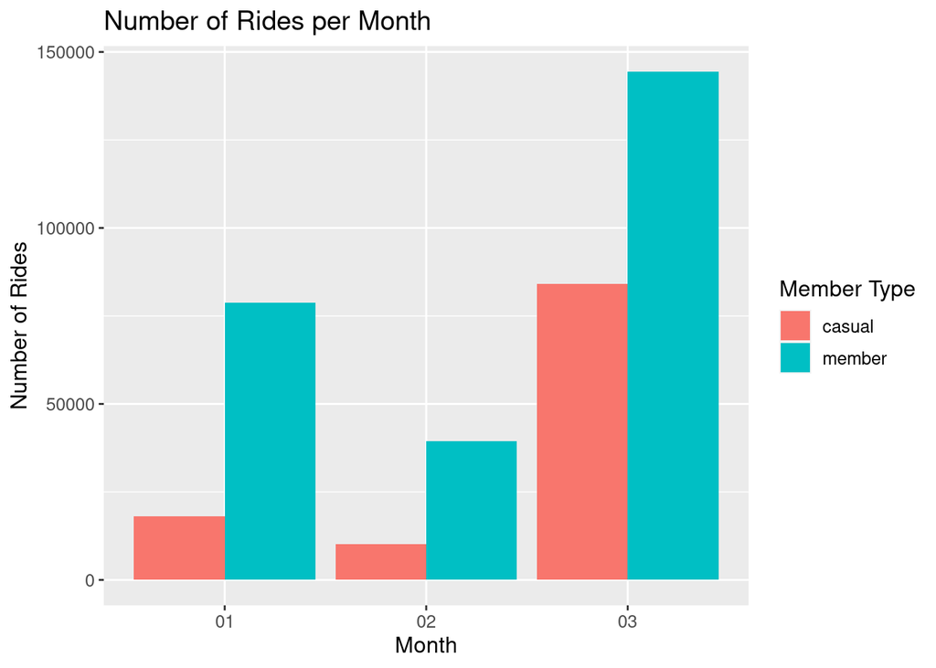

[figure not shown]

```r
#arranges months in order

bike_df_2$month <- ordered(bike_df_2$month, levels=c("01", "02", "03", "04", "05", "06", "07","08","09","10","11","12"))

#plot number of rides per month

ggplot(data = bike_df_2) +
  aes(x = month, fill = member_type) +
  geom_bar(position = 'dodge') +
  labs(x = 'Month', y = 'Number of Rides', fill = 'Member Type', title = 'Number of Rides per Month') +
  theme(text=element_text(size=12))
```

**Graph 5: Trip Duration by Member Type by Day of Week**

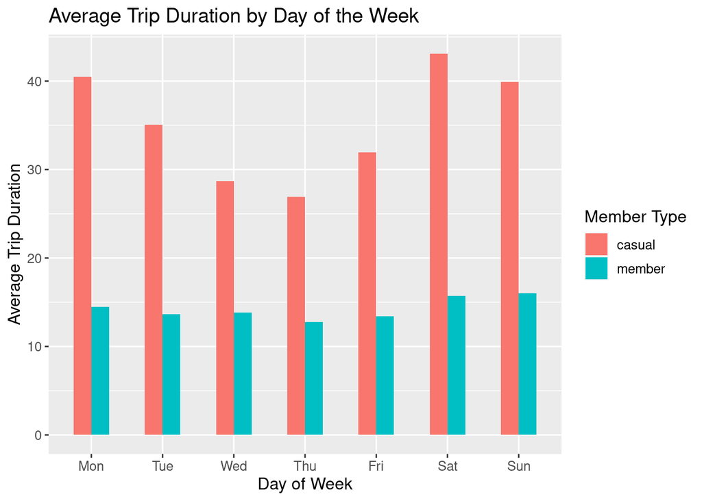

[figure not shown]

```r
#Average ride duration per customer type per day

bike_df_2 %>%
  group_by(member_type, day_of_week) %>%
  summarise(average_trip_duration = mean(trip_duration)) %>%
  ggplot(aes(x = day_of_week, y = average_trip_duration, fill = member_type)) +
  geom_col(width=0.5, position = position_dodge(width=0.5)) +
  labs(x = 'Day of Week', y = 'Average Trip Duration', fill = 'Member Type', title ="Average Trip Duration by Day of the Week")+
  theme(text=element_text(size=12))
```

Based on this data, we see that casual riders average ride time is longer than members.

**Top 10 popular starting stations for Casual Riders**

```r
#Top 10 popular start station for casual riders

bike_df_2 %>%
  group_by(member_type, start_station_name) %>%
  dplyr::summarise(Rides = n()) %>%
  filter(start_station_name != "", "casual"== member_type) %>%
  arrange(-Rides) %>%
  head(n=10) %>%
  select(-member_type)
```

```
## # A tibble: 10 × 3
## # Groups:   member_type [1]
##    member_type start_station_name           Rides
##    <chr>       <chr>                        <int>
##  1 casual      Lake Shore Dr & Monroe St     2192
##  2 casual      Millennium Park               1683
##  3 casual      Streeter Dr & Grand Ave       1667
##  4 casual      Shedd Aquarium                1206
##  5 casual      Indiana Ave & Roosevelt Rd     985
##  6 casual      Michigan Ave & Oak St          966
##  7 casual      Theater on the Lake            907
##  8 casual      Michigan Ave & Washington St   897
##  9 casual      Clark St & Elm St              858
## 10 casual      Wells St & Elm St              837
```

We see that casual riders start their ride near tourist destinations of Chicago.

**Top 10 popular starting stations for member riders.**

```r
#Top 10 popular start station for member riders

bike_df_2 %>%
  group_by(member_type,start_station_name) %>%
  dplyr::summarise(Rides = n()) %>%
  filter(start_station_name != "", "member" == member_type) %>%
  arrange(-Rides) %>%
  head(n=10) %>%
  select(-member_type)
```

```
## # A tibble: 10 × 3
## # Groups:   member_type [1]
##    member_type start_station_name        Rides
##    <chr>       <chr>                     <int>
##  1 member      Clark St & Elm St          2598
##  2 member      Dearborn St & Erie St      2378
##  3 member      Kingsbury St & Kinzie St   2171
##  4 member      St. Clair St & Erie St     2028
##  5 member      Wells St & Huron St        1989
##  6 member      Wells St & Elm St          1945
##  7 member      Wells St & Concord Ln      1878
##  8 member      Columbus Dr & Randolph St  1825
##  9 member      Desplaines St & Kinzie St  1728
## 10 member      Broadway & Barry Ave       1651
```

We can now answer the following questions after analyzing the data:

**3. What surprises did you discover in the data?**

- Classic bikes were more popular than electric bikes for both member types. this is surprising as I thought people would prefer electric-assisted bikes.
- Member riders did not use docked bikes. I assume members prefer docked bikes because they are more familiar with the company systems. I’d imagine members would gear toward secured bikes after consistently using the bikes.
- Casual rider’s trip duration was longer than members’ trip duration.

### Act

In this phase, we will translate our data analytics to communicate actionable insights for the Divvy Marketing Team.

The questions include the following:

**1. What is your final conclusion based on your analysis?**

- Increase memberships by investing in start stations near the financial/tech district for employees to commute to work
- Phase out docked bicycles and increase the fleet of regular and electric bike
- Partner with local employers to encourage employees to commute by bicycle
- Increase marketing during early spring and summer to maximize demand during this season
- Offer membership promotions to casual members at popular start and end stations
- Start a rewards program to increase the value proposition of membership status

**2. Is there additional data you could use to expand on your findings?**

Additional data that could expand our findings is the reason for riding our bikes. We can gather this data by launching a dichonomous survey before each ride through the app. Gathering data about ride distance will also provide meaningful insights.

### Recources

Special thanks to Itamar on Kaggle and Joe Yong on Medium for assisting me with this case study! Their projects are listed below.

- [kaggle](https://www.kaggle.com/code/itamargn/cyclistic-case-study/report)
- [Medium](https://medium.com/@joeanselmyz/google-data-analytics-case-study-1-using-rstudio-7c552ab63aa3)